# week3_assignment_2019313106홍현경

Hyungyeong Hong

3/23/2021

## Chapter 1. 모델링을 위한 전처리

### 문제 0. 기본 세팅

```r
# 라이브러리 불러오기
library(tidyverse)
library(data.table)
library(gridExtra)

# 파일 경로 설정
setwd("C:/Users/hyung/Desktop/P-Sat/week3")

# 파일 불러오기
data <- fread("data.csv")
test <- fread("test.csv")
```

### [Train data(data.csv) 전처리 및 EDA]

### 문제 1. ’bmi’변수를 numeric자료형으로 바꾸고, NA값을 mean imputation으로 바꾸기

```r
data %>% head(10) # 불러온 data 형태 확인
```

```
##        id gender age hypertension heart_disease ever_married     work_type
##  1:  9046   Male  67            0             1          Yes       Private
##  2: 51676 Female  61            0             0          Yes Self-employed
##  3: 31112   Male  80            0             1          Yes       Private
##  4: 60182 Female  49            0             0          Yes       Private
##  5:  1665 Female  79            1             0          Yes Self-employed
##  6: 53882   Male  74            1             1          Yes       Private
##  7: 10434 Female  69            0             0           No       Private
##  8: 27419 Female  59            0             0          Yes       Private
##  9: 60491 Female  78            0             0          Yes       Private
## 10: 12109 Female  81            1             0          Yes       Private
##     Residence_type avg_glucose_level  bmi  smoking_status stroke
##  1:          Urban            228.69 36.6 formerly smoked      1
##  2:          Rural            202.21  N/A    never smoked      1
##  3:          Rural            105.92 32.5    never smoked      1
##  4:          Urban            171.23 34.4          smokes      1
##  5:          Rural            174.12   24    never smoked      1
##  6:          Rural             70.09 27.4    never smoked      1
##  7:          Urban             94.39 22.8    never smoked      1
##  8:          Rural             76.15  N/A         Unknown      1
##  9:          Urban             58.57 24.2         Unknown      1
## 10:          Rural             80.43 29.7    never smoked      1
```

```r
data$bmi <- data$bmi %>% as.numeric # bmi 변수 numeric으로 바꾸기
data$bmi <- data$bmi %>% replace_na(., mean(., na.rm=TRUE)) # mean imputation #tidyverse의 replace_na() 이용

data$bmi %>% is.na %>% sum # NA 지워졌는지 확인
```

```
## [1] 0
```

### 문제 2. 문자형(character) 변수를 명목형 변수(factor)로 바꾸기

- select(where(is.character)) 에서 where() 쓰지 않았을 때 Predicate functions must be wrapped in `where()`이라는 경고 메시지가 출력되어 수정함

```r
char_cols <- data %>% select(is.character) %>% colnames # character형 변수명 뽑아내기
```

```
## Warning: Predicate functions must be wrapped in `where()`.
##
##   # Bad
##   data %>% select(is.character)
##
##   # Good
##   data %>% select(where(is.character))
##
## i Please update your code.
## This message is displayed once per session.
```

```r
data[,char_cols] <- data %>% select(where(is.character)) %>% lapply(as.factor) # character형 변수를 factor로 바꾼 후 data 업데이트
```

### 문제 3. ‘id’ 변수 제거

```r
data <- data %>% select(-"id") # data의 id 변수 제거, tidyverse(dplyr)의 select 이용
```

### 문제 4. 타겟(stroke)값 별로 범주형 변수의 분포를 시각화 하고 해석하기

- heart_disease, hypertension, stroke 변수 역시 0과 1로 구분되어 있으므로 factor 처리
- 두 변수는 numeric meaning이 없는 범주형 자료에 해당함

```r
data$heart_disease <- data$heart_disease %>% as.factor
data$hypertension <- data$hypertension %>% as.factor
data$stroke  <- data$stroke %>% as.factor
```

- stroke 값에 따라 서로 다른 플랏을 그릴 것이기 때문에 stroke 값에 따라 범주형 데이터를 분리함
- 각 변수별로 해당 변수 내의 카테고리가 stroke의 해당 값에서 차지하는 비율 구해야 하므로 변수들을 모두 gather처리하여 variable 변수의 구성 요소로 저장, 기존 변수의 값들은 value 변수의 구성 요소로 저장
- select(all_of(cols), “stroke”)에서 all_of() 쓰지 않았을 때 Note: Using an external vector in selections is ambiguous.가 출력되어 수정함

```r
# factor_cols: 범주형 자료 변수 이름 벡터
factor_cols <- data %>% select(where(is.factor)) %>% colnames

stroke1_df <- data %>% select(all_of(factor_cols)) %>%
  filter(stroke==1) %>% gather(key="variable", value="value", -stroke) %>%
  select(-stroke)
stroke0_df <- data %>% select(all_of(factor_cols)) %>%
  filter(stroke==0) %>% gather(key="variable", value="value", -stroke) %>%
  select(-stroke)

# gather()의 결과 확인
stroke1_df %>% head(10)
```

```
##    variable  value
## 1    gender   Male
## 2    gender Female
## 3    gender   Male
## 4    gender Female
## 5    gender Female
## 6    gender   Male
## 7    gender Female
## 8    gender Female
## 9    gender Female
## 10   gender Female
```

```r
stroke0_df %>% head(10)
```

```
##    variable  value
## 1    gender   Male
## 2    gender   Male
## 3    gender Female
## 4    gender Female
## 5    gender   Male
## 6    gender Female
## 7    gender Female
## 8    gender Female
## 9    gender Female
## 10   gender Female
```

- stroke 값에 따라 서로 다른 플랏을 그린 후 grid.arrange()를 이용하여 두 플랏을 합침
- 플랏이 잘리는 문제가 발생해 fig.width=15, fig.height=6를 code chunk 앞부분에 넣어줌

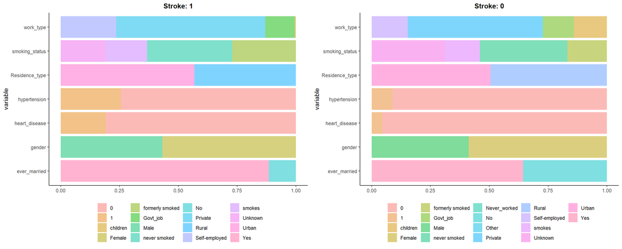

```r
bar_plot1 <- stroke1_df %>% ggplot(aes(x=variable, fill=value))+
  geom_bar(position="fill", alpha=0.5)+
  coord_flip()+
  ggtitle("Stroke: 1")+
  ylab(NULL)+
  theme_classic()+
  theme(plot.title=element_text(face="bold", size=12, hjust=0.5), legend.position="bottom", legend.title=element_blank())

bar_plot0 <- stroke0_df %>% ggplot(aes(x=variable, fill=value))+
  geom_bar(position="fill", alpha=0.5)+
  coord_flip()+
  ggtitle("Stroke: 0")+
  ylab(NULL)+
  theme_classic()+
  theme(plot.title=element_text(face="bold", size=12, hjust=0.5), legend.position="bottom", legend.title=element_blank())

grid.arrange(bar_plot1, bar_plot0, ncol=2)
```

[해석] stroke 값이 1인 플랏을 보면, work_type 변수에서는 Private가 가장 높은 비율을 차지했다. Smoking_status에서는 never smoked, Residance_type에서는 Urban, hypertension과 heart_disease에서는 0, gender에서는 Female, ever_married에서는 Yes가 가장 높은 비율을 보였다. stroke 값이 0인 플랏을 보면, work_type 변수에서는 Private가 가장 높은 비율을 차지했다. Smoking_status에서는 never smoked와 unknown이 비슷한 비율로 높고, Residance_type에서는 Urban과 Rural이 비슷한 비율을 보였다. 또한, hypertension과 heart_disease에서는 0, gender에서는 Female, ever_married에서는 Yes가 가장 높은 비율을 보였다.

### 문제 5. 타겟(stroke) 값 별로 수치형 변수의 분포를 시각화 한 후 간단히 해석

- stroke 값에 따라 서로 다른 플랏을 그릴 것이기 때문에 stroke 값에 따라 수치형 데이터를 분리함

```r
# num_cols: 수치형 자료 변수 이름 벡터
num_cols <- data %>% select(where(is.numeric)) %>% colnames

stroke1_df <- data %>% select(all_of(num_cols), "stroke") %>%
  filter(stroke==1) %>% gather(key="variable", value="value", -stroke) %>%
  select(-stroke)
stroke0_df <- data %>% select(all_of(num_cols), "stroke") %>%
  filter(stroke==0) %>% gather(key="variable", value="value", -stroke) %>%
  select(-stroke)

# gather()의 결과 확인
stroke1_df %>% head(10)
```

```
##    variable value
## 1       age    67
## 2       age    61
## 3       age    80
## 4       age    49
## 5       age    79
## 6       age    74
## 7       age    69
## 8       age    59
## 9       age    78
## 10      age    81
```

```r
stroke0_df %>% head(10)
```

```
##    variable value
## 1       age     3
## 2       age    58
## 3       age     8
## 4       age    70
## 5       age    14
## 6       age    47
## 7       age    52
## 8       age    75
## 9       age    32
## 10      age    74
```

- stroke 값에 따라 서로 다른 플랏을 그린 후 grid.arrange()를 이용하여 두 플랏을 합침
- 플랏이 잘리는 문제가 발생해 fig.width=10, fig.height=6를 code chunk 앞부분에 넣어줌

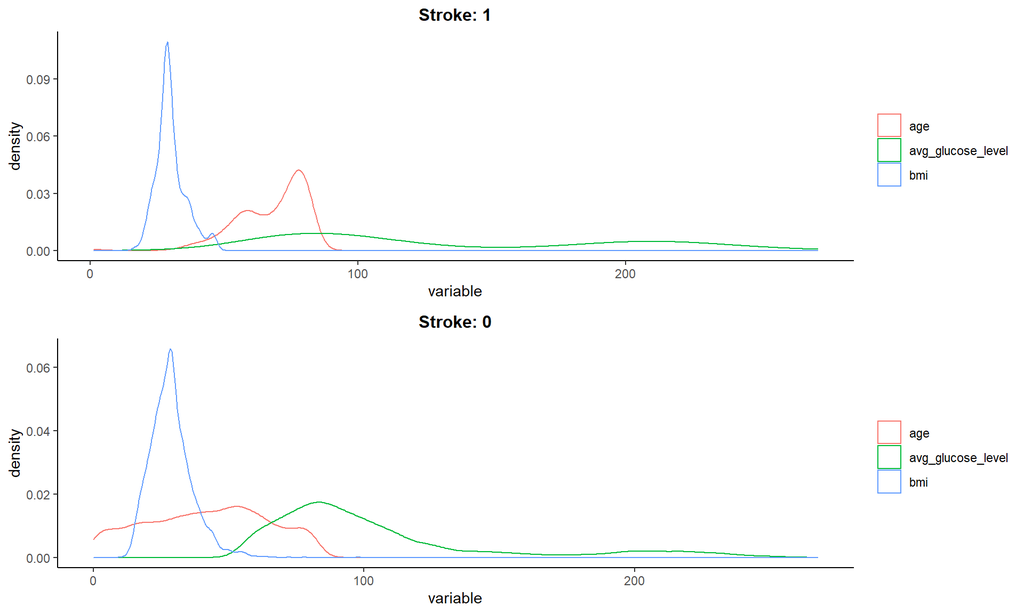

```r
density_plot1 <- stroke1_df %>% ggplot(aes(x=value, color=variable))+
  geom_density()+
  ggtitle("Stroke: 1", )+
  xlab("variable")+
  ylab("density")+
  theme_classic()+
  theme(plot.title=element_text(face="bold", size=12, hjust=0.5), legend.title=element_blank())

density_plot0 <- stroke0_df %>% ggplot(aes(x=value, color=variable))+
  geom_density()+
  ggtitle("Stroke: 0", )+
  xlab("variable")+
  ylab("density")+
  theme_classic()+
  theme(plot.title=element_text(face="bold", size=12, hjust=0.5), legend.title=element_blank())

grid.arrange(density_plot1, density_plot0, nrow=2)
```

[해석] stroke값이 1인 경우를 보면, 특정 bmi에서 density가 매우 높게 나타나는 것을 알 수 있다. age의 경우 stroke보다는 첨도가 낮으나 역시 100보다 조금 작은 값에서 density가 높게 나타나는 것을 볼 수 있다. avg_glucose_level은 균등하게 분포되어 있다. stroke값이 0인 경우를 보면, 특정 bmi에서 density가 매우 높게 나타나는 것을 알 수 있다. age의 경우 100보다 미만의 값에서 density가 균등하게 나타나는 것을 볼 수 있다. avg_glucose_level은 100보다 조금 작은 값에서 비교적 높은 density가 관찰된다.

### 문제 6. 타겟 변수와 범주형 변수에 대한 카이스퀘어 독립성 검정 진행

```r
chi_df <- data.frame(cate_var=rep(NA,7), chi=rep(NA,7))

categorical_df <- data %>% select(all_of(factor_cols)) %>% as.data.frame

for(i in 1:7)
{
  x <- categorical_df[,i]
  y <- data$stroke
  result <- chisq.test(x,y)
  chi_df$cate_var[i] <- colnames(categorical_df)[i]
  chi_df$chi[i] <- ifelse(result$p.value<0.05, "denied", "accept")
}

chi_df
```

```
##         cate_var    chi
## 1         gender accept
## 2   hypertension denied
## 3  heart_disease denied
## 4   ever_married denied
## 5      work_type denied
## 6 Residence_type accept
## 7 smoking_status denied
```

### 문제 7. 카이스퀘어 독립성 검정에서 가설을 기각하지 못한 범주형 변수 제거

```r
accept_var <- chi_df[which(chi_df[,2]=="accept"),1]
data <- data %>% select(-all_of(accept_var))
```

### [Test data(test.csv) 전처리]

### 문제 8. train data에서 했던 전처리 방법 이용하여 test data 전처리

```r
test$bmi <- test$bmi %>% as.numeric # bmi 변수 numeric으로 바꾸기
test$bmi <- test$bmi %>% replace_na(., mean(., na.rm=TRUE)) # mean imputation #tidyverse의 replace_na() 이용

char_cols <- test %>% select(is.character) %>% colnames # character형 변수명 뽑아내기
test[,char_cols] <- test %>% select(where(is.character)) %>% lapply(as.factor) # character형 변수를 factor로 바꾼 후 data 업데이트

test <- test %>% select(-"id") # test의 id 변수 제거, tidyverse(dplyr)의 select 이용

test$heart_disease <- test$heart_disease %>% as.factor
test$hypertension <- test$hypertension %>% as.factor

test <- test %>% select(-all_of(accept_var))
```

## Chapter 2. Catboost

### 문제 0. Catboost 모델의 특성 및 대표적인 파라미터에 대한 간략한 설명

```r
library(catboost)
library(caret)
library(MLmetrics)
```

[모델의 특성] * symmetric trees: CatBoost는 symmetric한 tree를 implement하여 예측 시간을 줄였다. * ordered boosting: 기존의 부스팅 모델은 모든 training set을 이용하여 잔차를 계산하지만 CatBoost는 일부의 training set만 가지고 잔차계산을 한 후 모델을 만들고, 이후의 잔차는 만든 모델을 이용하여 예측한 값을 사용한다. * random permutation: 오버피팅을 방지하고 트리를 다각적으로 만들기 위해 데이터의 순서를 섞어준다. * ordered target encoding: 범주형 변수를 숫자로 인코딩 할 때 현재 데이터의 인코딩을 위해서 이전 데이터의 인코딩 값을 사용한다. * categorical feature combinations: CatBoost는 여러개의 categorical features를 결합할 수 있다.

[대표적인 파라미터] * loss_funttion(the metric to use in training) * custom_loss(metric values to output during training) * eval_metric(the metric used for overfitting detection and best model selection) * iterations(the maximum number of trees) * learning_rate(the leatning rate, used for reducing the gradient step) * bootstrap_type(defines the method for sampling the weights of objects) * subsample(sample rate for bagging) * depth(depth of the tree) * l2_leaf_reg(coefficient at the L2 regularization term of the cost function) * ignored_features(feature indices to exclude from the training)

### 문제 1. expand.grid를 사용하여 데이터 프레임 생성

```r
logloss_cb <- expand.grid(depth=c(4,6,8), iterations=c(100,200), logloss=NA)
logloss_cb
```

```
##   depth iterations logloss
## 1     4        100      NA
## 2     6        100      NA
## 3     8        100      NA
## 4     4        200      NA
## 5     6        200      NA
## 6     8        200      NA
```

### 문제 2. catboost에 대해 depth와 iteration 파라미터 튜닝을 위한 grid search 5-fold cv 진행

```r
# data를 data frame 형태로 변환 후 train에 저장
train <- data %>% as.data.frame

# 범주형 자료 인덱스
cat_idx <- c(4, 5, 8)
factor_idx <- c(2, 3, 9)

# 범주형 자료 수치화
for(i in cat_idx)
{
  train[,i] <- as.numeric(factor(train[,i]))
}

for(i in factor_idx)
{
  train[,i] <- as.numeric(train[,i])
}

# 타겟 변수의 인덱스
target <- which(colnames(train)=="stroke")

# 모델에 맞는 데이터 형식으로 변환
train_pool <- catboost.load_pool(data=train[,-target], label=train[,target])

# training
set.seed(1234)
start_time <- Sys.time() # start training

for (i in 1:6){
  model_params = list(loss_function="Logloss", depth=logloss_cb[i,1], iterations=logloss_cb[i,2])
  cb_result <- catboost.cv(train_pool, params=model_params, fold_count=5)
  logloss_cb$logloss[i] <- cb_result$test.Logloss.mean %>% mean
}
end_time <- Sys.time() # end training
```

- logloss_cb를 통해 결과 확인 및 걸린 시간 측정

```r
# logloss_cb 확인
logloss_cb
```

```
##   depth iterations   logloss
## 1     4        100 0.2212242
## 2     6        100 0.2197960
## 3     8        100 0.2179104
## 4     4        200 0.1896432
## 5     6        200 0.1898073
## 6     8        200 0.1902339
```

```r
# 걸린 시간 확인
end_time-start_time
```

```
## Time difference of 3.331698 mins
```

### 문제 3. logloss_cb에서 가장 낮은 logloss값의 행 출력

```r
logloss_cb[which.min(logloss_cb$logloss),]
```

```
##   depth iterations   logloss
## 4     4        200 0.1896432
```

### 문제 4. 가장 낮은 logloss 값의 파라미터로 전체 데이터를 학습시켜 test set에 대한 logloss값 구하기

- 가장 낮은 logloss 값의 파라미터로 전체 데이터 학습시키기

```r
cb_model <- catboost.train(train_pool, params=list(loss_function="Logloss", depth=4, iterations=200))
```

- test set에 대한 logloss값 구하기
- 이상하다…모르겠다…문제 2번부터 무언가 잘못되었다…

```r
# test를 data frame 형태로 변환 후 train에 저장
test <- test %>% as.data.frame

# 범주형 자료 인덱스
cat_idx <- c(4, 5, 8)
factor_idx <- c(2, 3, 9)

# 범주형 자료 수치화
for(i in cat_idx)
{
  test[,i] <- as.numeric(factor(test[,i]))
}

for(i in factor_idx)
{
  test[,i] <- as.numeric(test[,i])
}

# 타겟 변수의 인덱스
target <- which(colnames(test)=="stroke")

# 모델에 맞는 데이터 형식으로 변환
test_pool <- catboost.load_pool(data=test[,-target], label=test[,target])

# prediction
catboost.predict(cb_model,test_pool) %>% mean
```

```
## [1] -4.2843
```

## Chapter 3. K-means Clustering

```r
library(factoextra)
library(cluster)
```

### 문제 1. 수치형 변수에 대해 scale 함수로 정규화 스케일링

```r
data_scaled <- data %>% select(where(is.numeric)) %>% scale
```

### 문제 2. fviz_nbclust 함수로 시각화 후, 적절한 k값이 무엇인지 설명

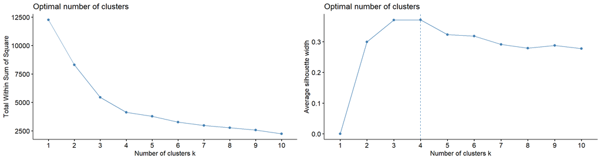

```r
k_plot1 <- data_scaled %>% fviz_nbclust(kmeans, method="wss")
k_plot2 <- data_scaled %>% fviz_nbclust(kmeans, method="silhouette")
grid.arrange(k_plot1, k_plot2, ncol=2)
```

적절한 k값은 클러스터 내에서 클러스터의 중심과 데이터 사이의 거리에 대한 제곱합을 최소화한다.

### 문제 3. k-means clustering을 한 후, 시각화

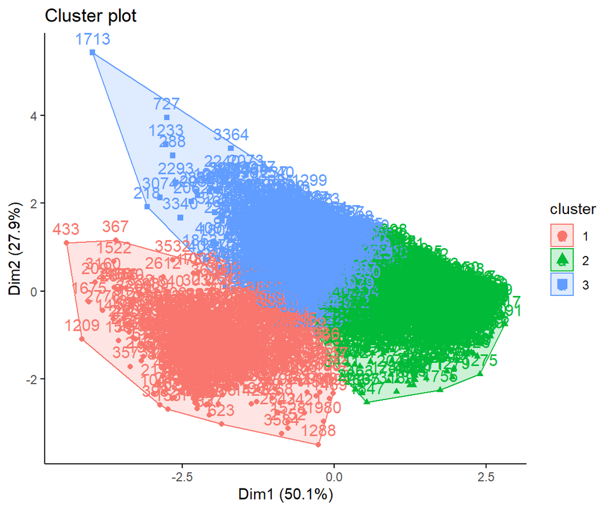

```r
set.seed(1234)
kmeans_result <- data_scaled %>% kmeans(center=3, nstart=1, iter.max=30)
fviz_cluster(kmeans_result, data=data_scaled, ggtheme=theme_classic())
```

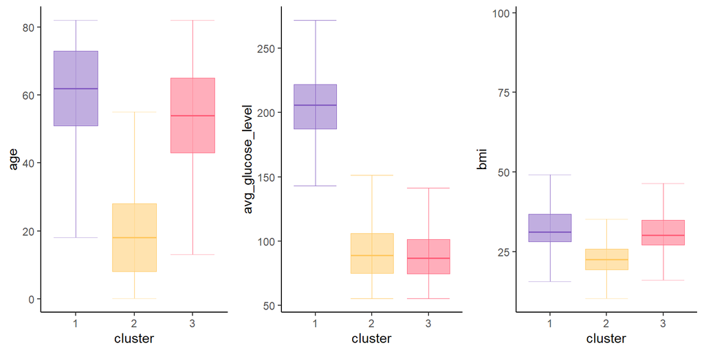

```r
cluster_df <- cbind(data, cluster=as.factor(kmeans_result$cluster)) # cluster factor 처리 해줘야 함

plot_age <- cluster_df %>% ggplot(aes(x=cluster, y=age, group=cluster, color=cluster, fill=cluster))+
  geom_boxplot(outlier.shape = NA, alpha=0.5, lwd=0.3)+
  stat_boxplot(geom="errorbar", alpha=0.5, lwd=0.3)+
  scale_fill_manual(breaks=c(1, 2, 3), values=c("#845ec2", "#ffc75f", "#ff5e78"))+
  scale_color_manual(breaks=c(1, 2, 3), values=c("#845ec2", "#ffc75f", "#ff5e78"))+
  theme_classic()+
  theme(legend.position="none")

plot_glucose <- cluster_df %>% ggplot(aes(x=cluster, y=avg_glucose_level, group=cluster, color=cluster, fill=cluster))+
  geom_boxplot(outlier.shape = NA, alpha=0.5, lwd=0.3)+
  stat_boxplot(geom="errorbar", lwd=0.3)+
  scale_fill_manual(breaks=c(1, 2, 3), values=c("#845ec2", "#ffc75f", "#ff5e78"))+
  scale_color_manual(breaks=c(1, 2, 3), values=c("#845ec2", "#ffc75f", "#ff5e78"))+
  theme_classic()+
  theme(legend.position="none")

plot_bmi <- cluster_df %>% ggplot(aes(x=cluster, y=bmi, group=cluster, color=cluster, fill=cluster))+
  geom_boxplot(outlier.shape = NA, alpha=0.5, lwd=0.3)+
  stat_boxplot(geom="errorbar", alpha=0.5, lwd=0.3)+
  scale_fill_manual(breaks=c(1, 2, 3), values=c("#845ec2", "#ffc75f", "#ff5e78"))+
  scale_color_manual(breaks=c(1, 2, 3), values=c("#845ec2", "#ffc75f", "#ff5e78"))+
  theme_classic()+
  theme(legend.position="none")

grid.arrange(plot_age, plot_glucose, plot_bmi, ncol=3)
```